# Data Analytics Practical 2

# Is there evidence for outliers in any of the variables? If so which one(s) and how many outliers can you identify? What do boxplots help us to see that Histograms don’t? Conversely, what do Histograms help us to see that boxplots don’t?

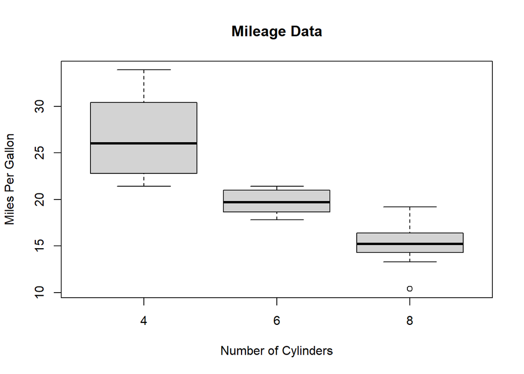

```r
boxplot(mpg ~ cyl, data = mtcars, xlab = "Number of Cylinders", ylab = "Miles Per Gallon", main = "Mileage Data")
```

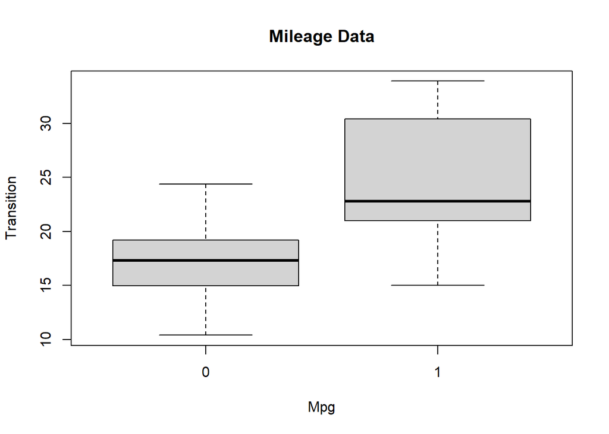

```r
boxplot(mpg ~ am, data = mtcars, xlab = "Mpg", ylab = "Transition", main = "Mileage Data")
```

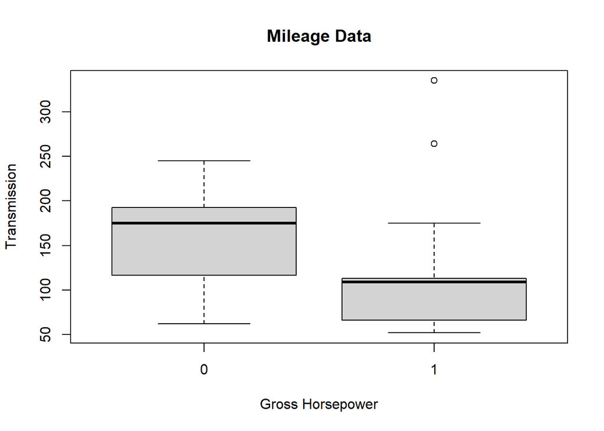

```r
boxplot(hp ~ am, data = mtcars, xlab = "Gross Horsepower", ylab = "Transmission", main = "Mileage Data")
```

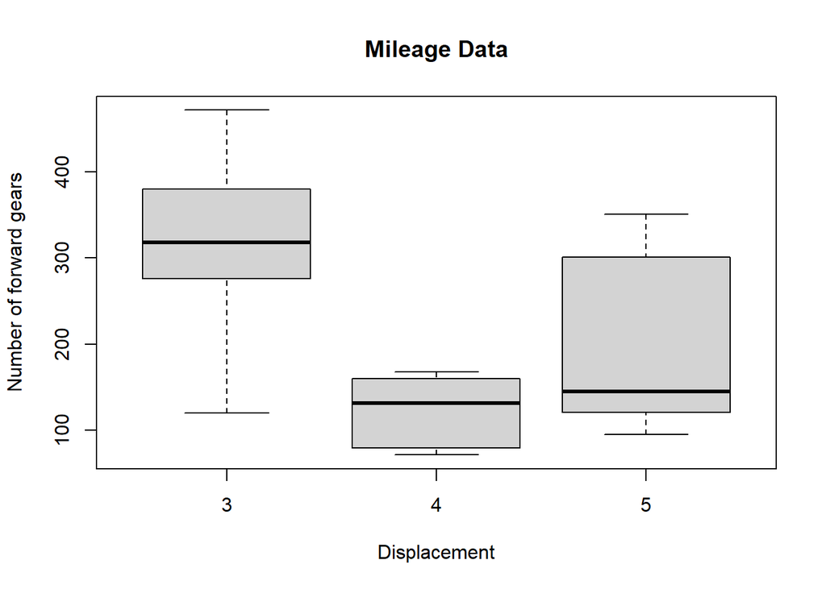

```r
boxplot(disp ~ gear, data = mtcars, xlab = "Displacement", ylab = "Number of forward gears", main = "Mileage Data")
```

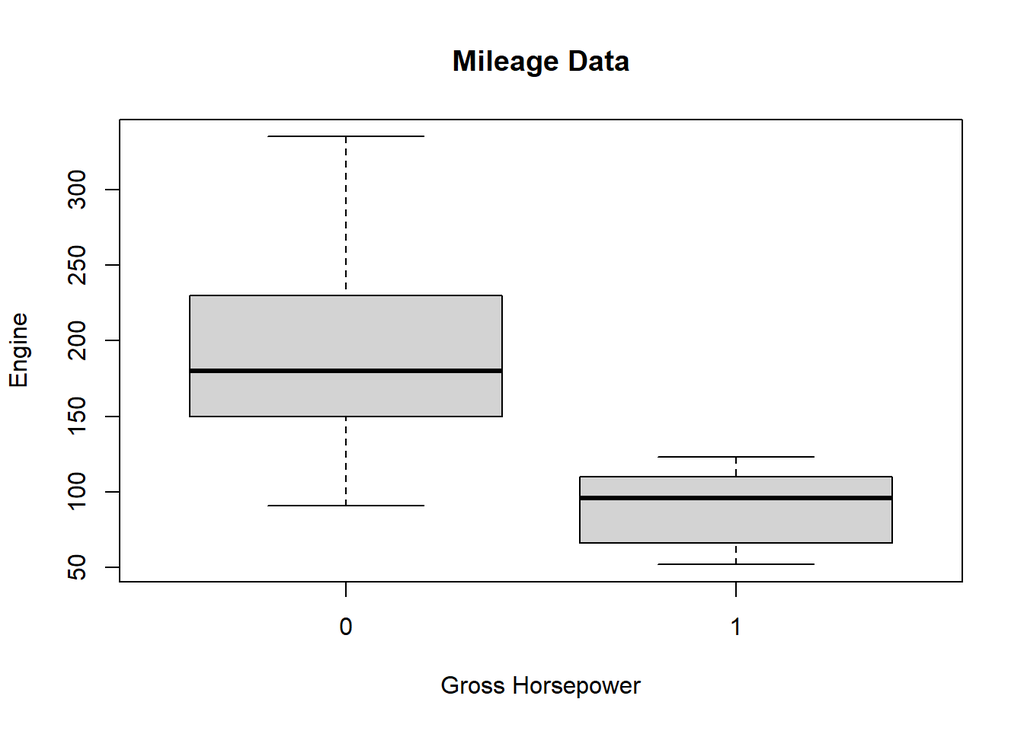

```r
boxplot(hp ~ vs, data = mtcars, xlab = "Gross Horsepower", ylab = "Engine", main = "Mileage Data")
```

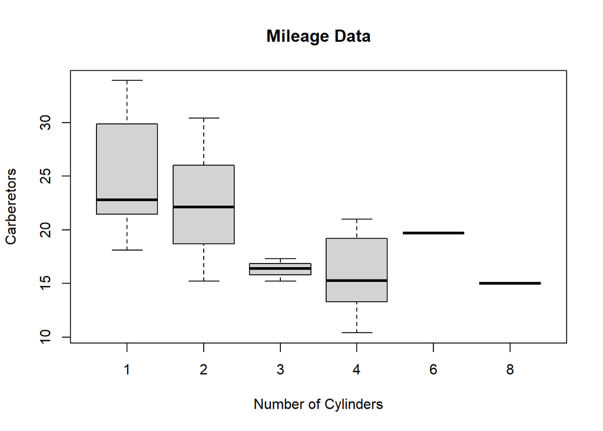

```r
boxplot(mpg ~ carb, data = mtcars, xlab = "Number of Cylinders", ylab = "Carberetors", main = "Mileage Data")
```

# 23. We might want to visualise the spread of a variable according to values of another variable. Try the code below:

# boxplot(mpg ~ cyl, data = mtcars, xlab = “Number of Cylinders”, ylab = “Miles Per Gallon”, main = “Mileage Data”)

# Describe in simple terms what is being shown in this plot.

# Mileage Data, Miles per Gallon, Number of Cylinders

# 24. Now create a boxplot visual to show each of the following relationships:

# b. Gross horsepower by Transmission

# c. Displacement by Number of Forward Gears

# d. Gross horsepower by Engine

# e. Mpg by Number of Carburettors

# Do you see any interesting relationships in these data? If so, describe at least 2 ofthem?

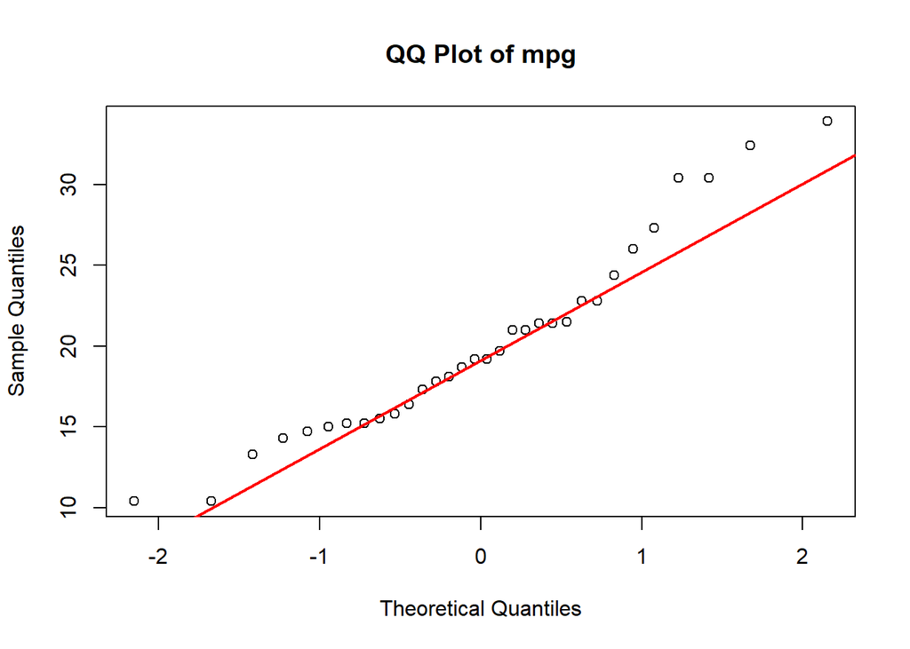

```r
qqnorm(mtcars$mpg, main = "QQ Plot of mpg", frame = TRUE)
qqline(mtcars$mpg, col = "red", lwd = 2)
```

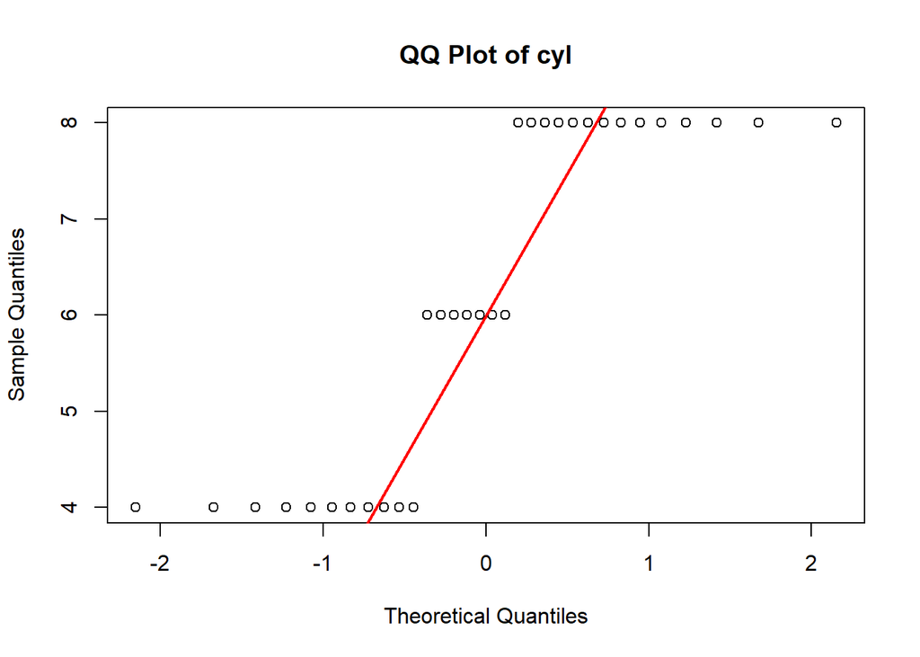

```r
qqnorm(mtcars$cyl, main = "QQ Plot of cyl", frame = TRUE)
qqline(mtcars$cyl, col = "red", lwd = 2)
```

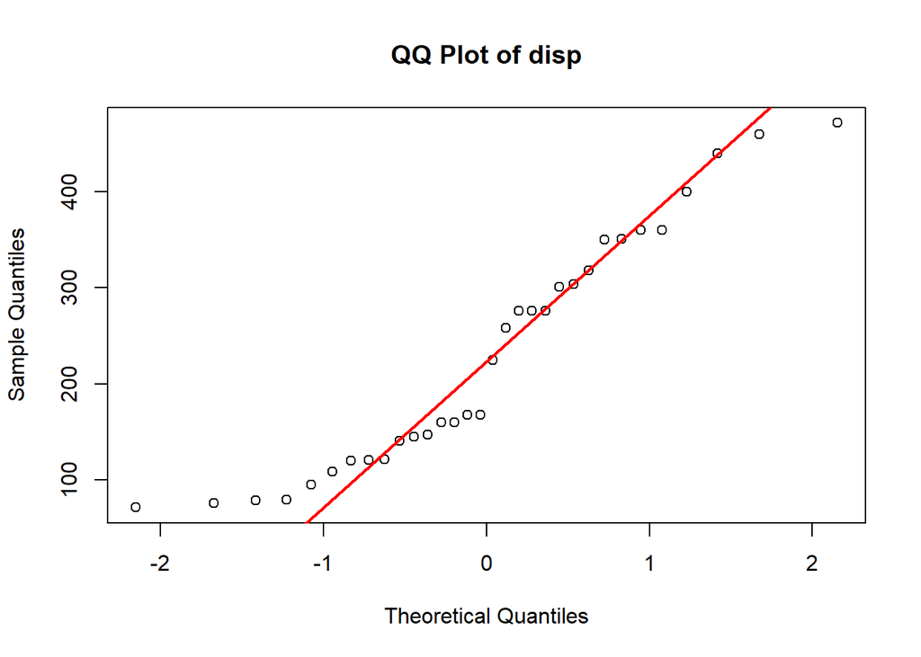

```r
qqnorm(mtcars$disp, main = "QQ Plot of disp", frame = TRUE)
qqline(mtcars$disp, col = "red", lwd = 2)
```

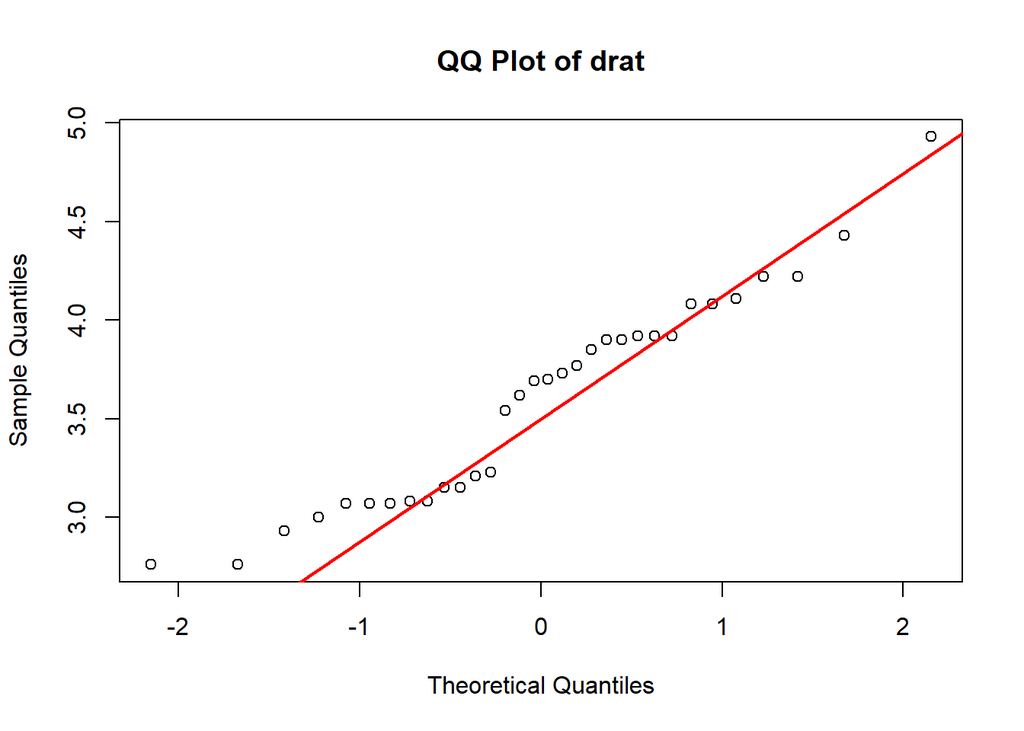

```r
qqnorm(mtcars$drat, main = "QQ Plot of drat", frame = TRUE)
qqline(mtcars$drat, col = "red", lwd = 2)
```

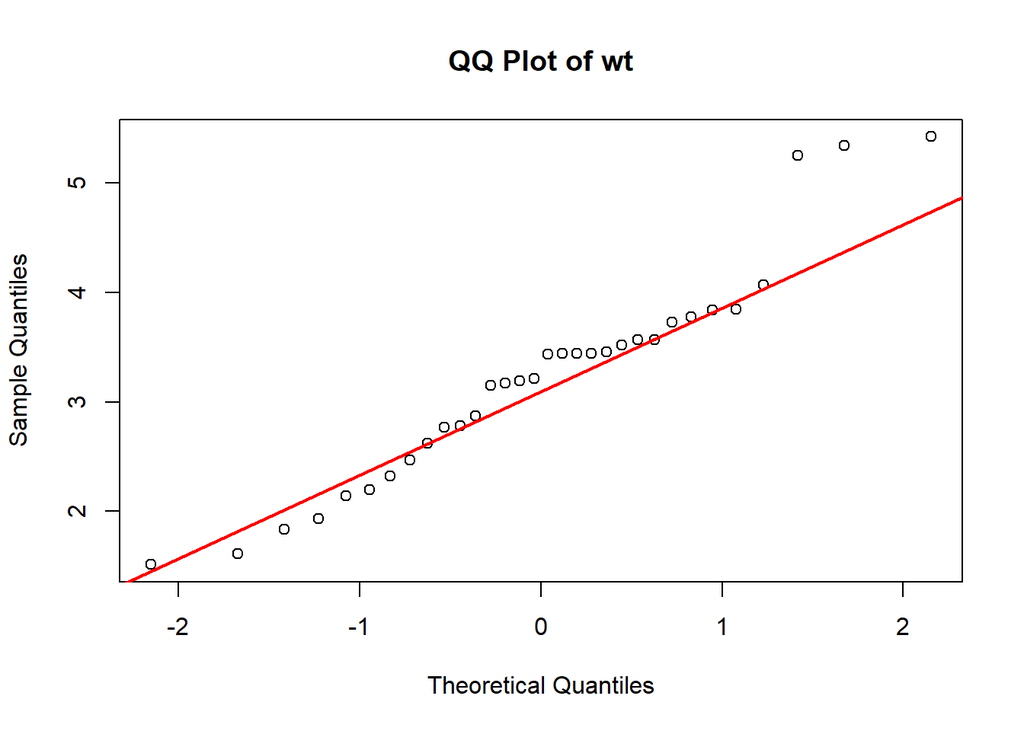

```r
qqnorm(mtcars$wt, main = "QQ Plot of wt", frame = TRUE)
qqline(mtcars$wt, col = "red", lwd = 2)
```

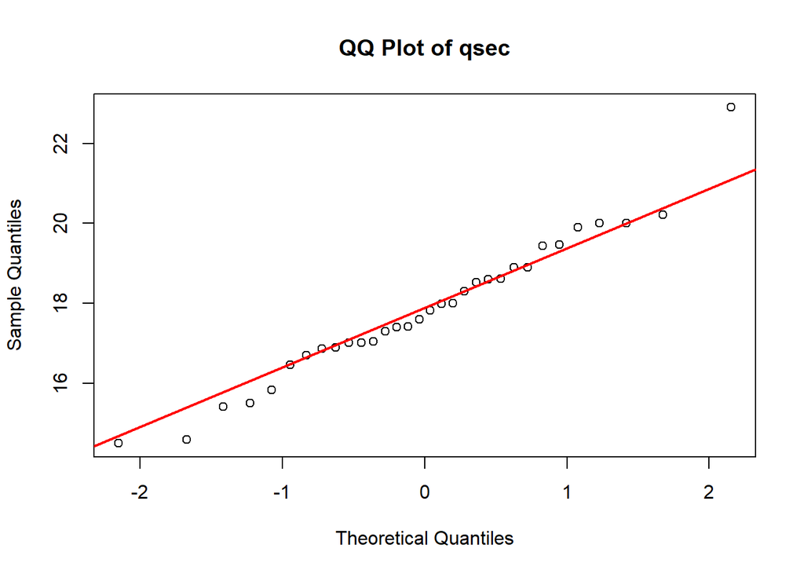

```r
qqnorm(mtcars$qsec, main = "QQ Plot of qsec", frame = TRUE)
qqline(mtcars$qsec, col = "red", lwd = 2)
```

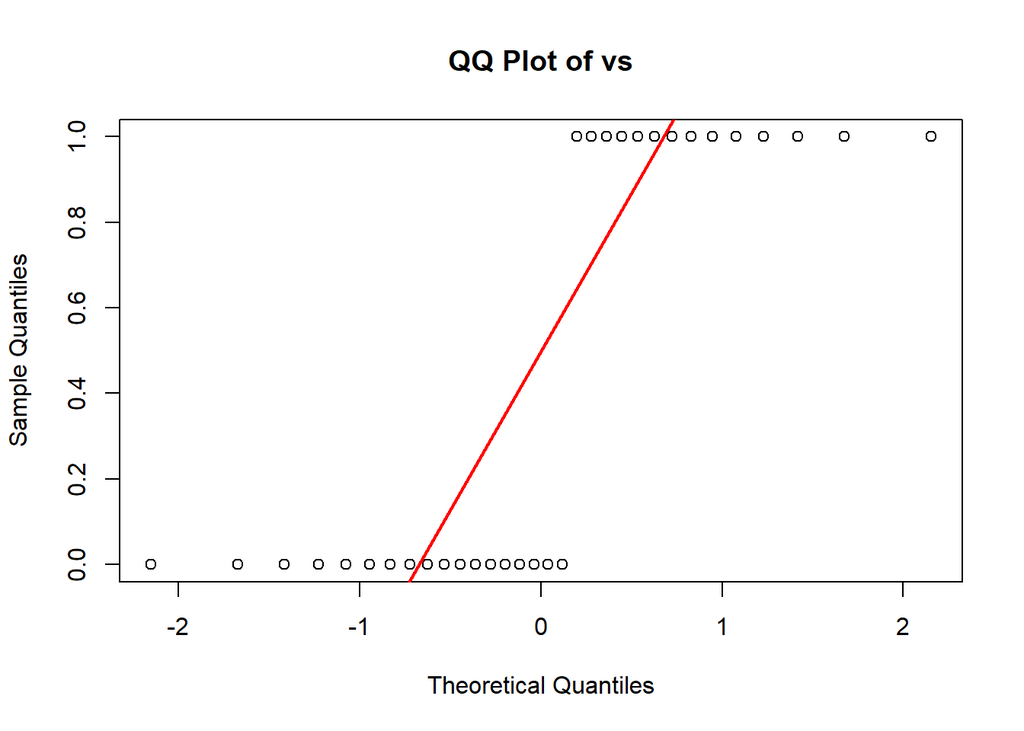

```r
qqnorm(mtcars$vs, main = "QQ Plot of vs", frame = TRUE)
qqline(mtcars$vs, col = "red", lwd = 2)
```

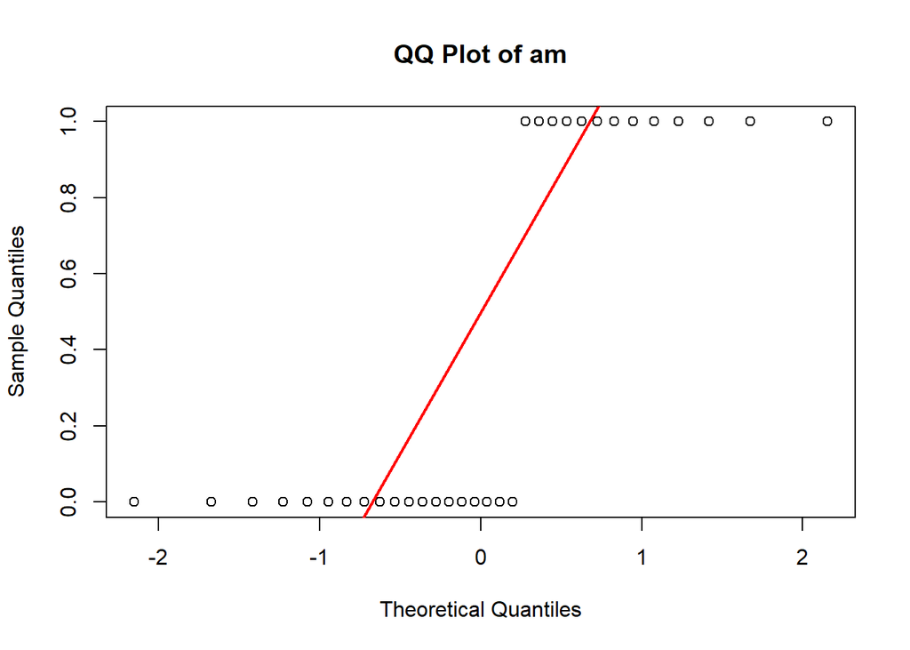

```r
qqnorm(mtcars$am, main = "QQ Plot of am", frame = TRUE)
qqline(mtcars$am, col = "red", lwd = 2)
```

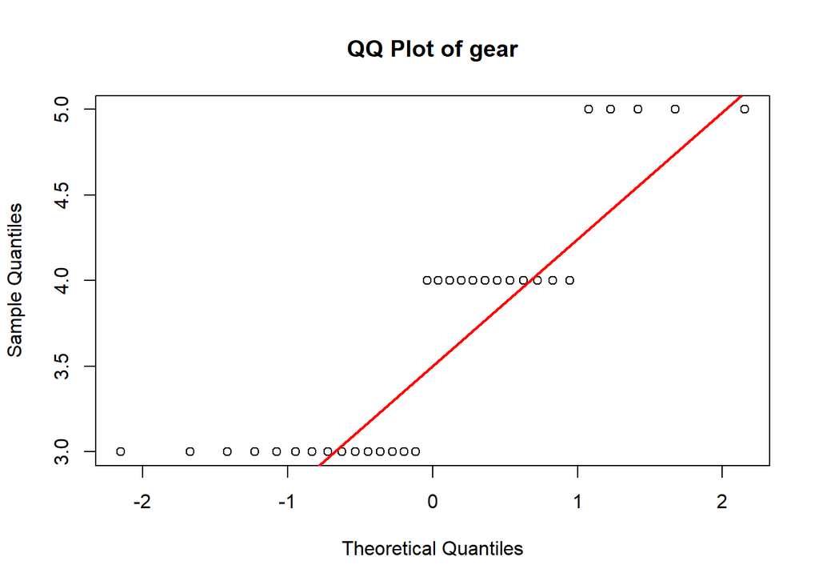

```r
qqnorm(mtcars$gear, main = "QQ Plot of gear", frame = TRUE)
qqline(mtcars$gear, col = "red", lwd = 2)
```

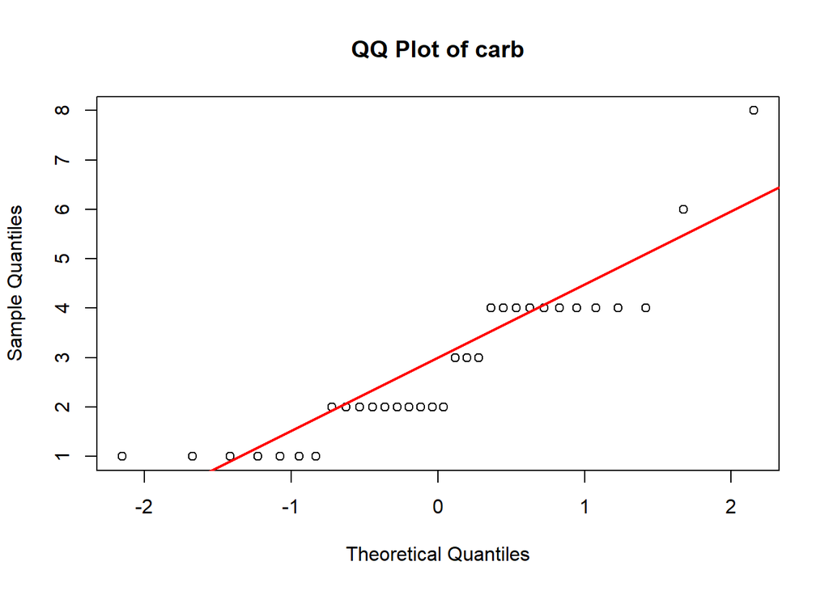

```r
qqnorm(mtcars$carb, main = "QQ Plot of carb", frame = TRUE)
qqline(mtcars$carb, col = "red", lwd = 2)
```

# 25. Note that we still don’t know that much about the distribution of the variables. # Create QQ Plots for the other relevant variables in mtcars.

```r
#install.packages("ggplot2") #installs a package, in this case- ggplot2.
#install.packages("gridExtra")
library("ggplot2") #loads an installed package
library("gridExtra")
```

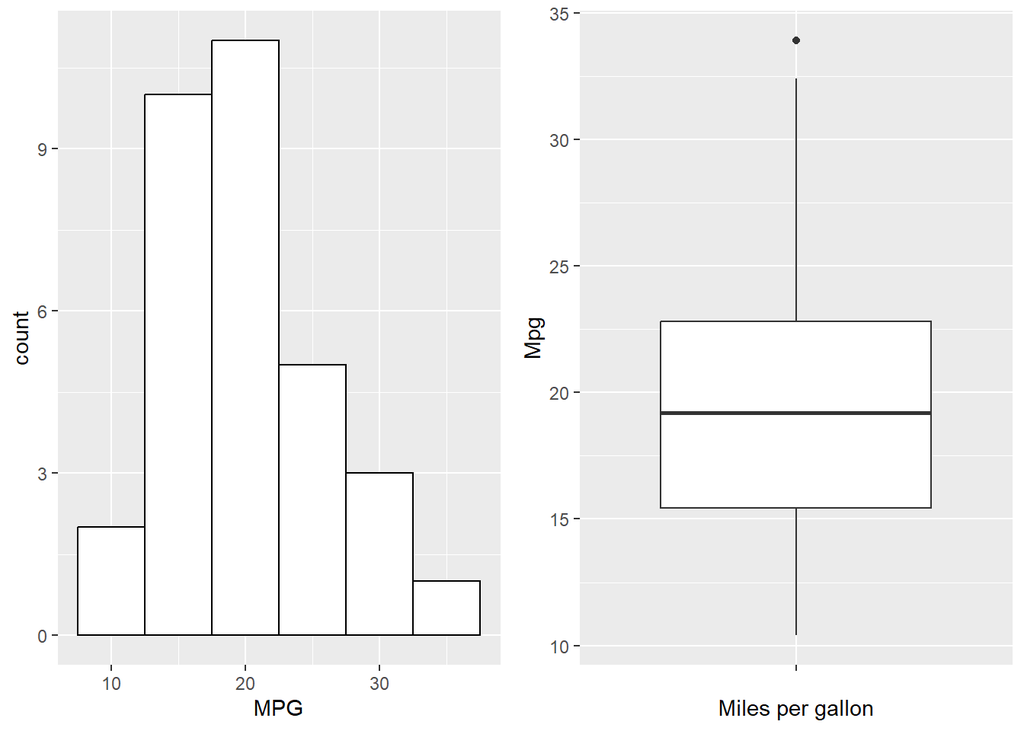

```r
library(ggplot2)
library(gridExtra)

box1<- ggplot(mtcars, aes(x="", y=mpg))+
 geom_boxplot()+
 xlab("Miles per gallon")+
 ylab("Mpg")
hist1<-ggplot(mtcars, aes(x=mpg))+
 geom_histogram(binwidth=5, fill="white", color="black")+
 xlab("MPG")
grid.arrange(hist1, box1, ncol=2)
```

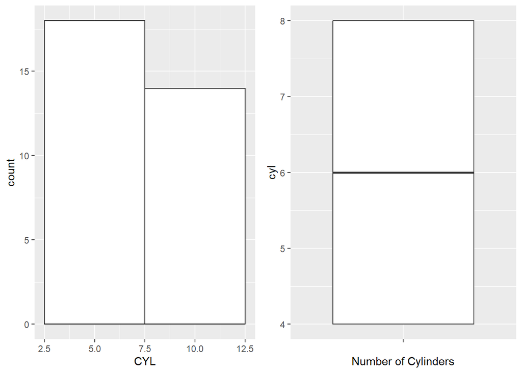

```r
box2<- ggplot(mtcars, aes(x="", y=cyl))+
 geom_boxplot()+
 xlab("Number of Cylinders")+
 ylab("cyl")
hist2<-ggplot(mtcars, aes(x=cyl))+
 geom_histogram(binwidth=5, fill="white", color="black")+
 xlab("CYL")
grid.arrange(hist2, box2, ncol=2)
```

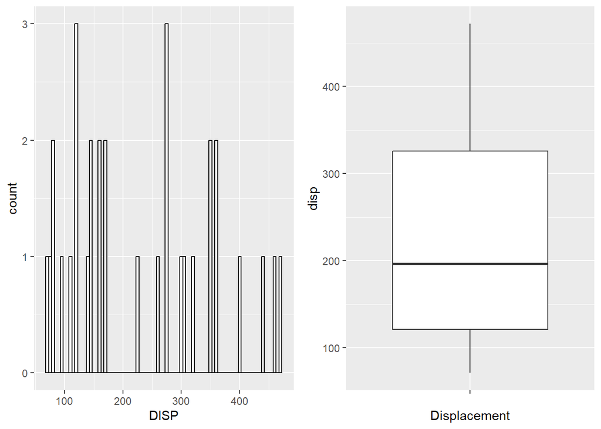

```r
box3<- ggplot(mtcars, aes(x="", y=disp))+
 geom_boxplot()+
 xlab("Displacement")+
 ylab("disp")
hist3<-ggplot(mtcars, aes(x=disp))+
 geom_histogram(binwidth=5, fill="white", color="black")+
 xlab("DISP")
grid.arrange(hist3, box3, ncol=2)
```

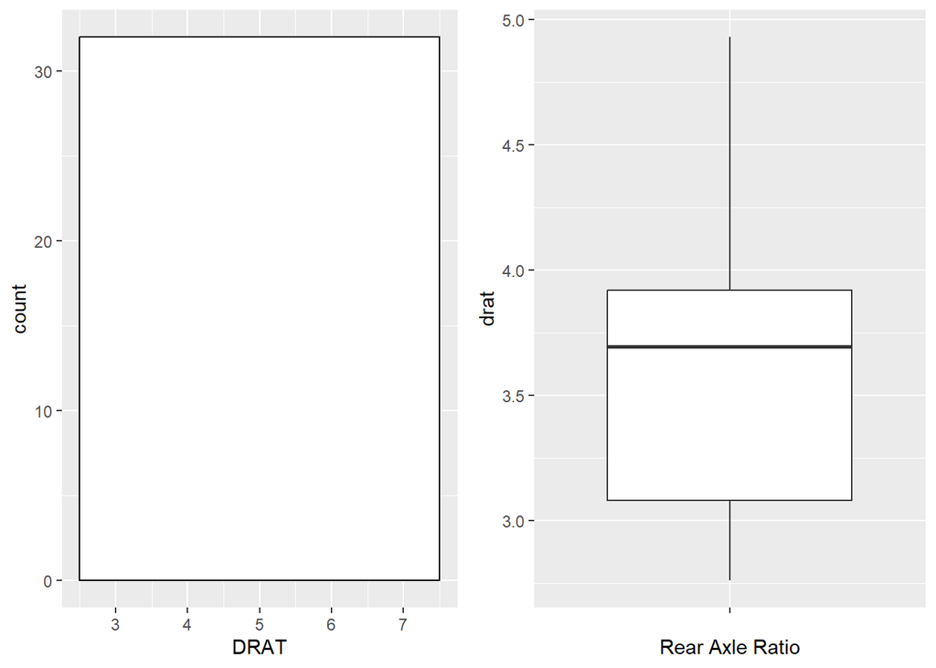

```r
box4<- ggplot(mtcars, aes(x="", y=drat))+
 geom_boxplot()+
 xlab("Rear Axle Ratio")+
 ylab("drat")
hist4<-ggplot(mtcars, aes(x=drat))+
 geom_histogram(binwidth=5, fill="white", color="black")+
 xlab("DRAT")
grid.arrange(hist4, box4, ncol=2)
```

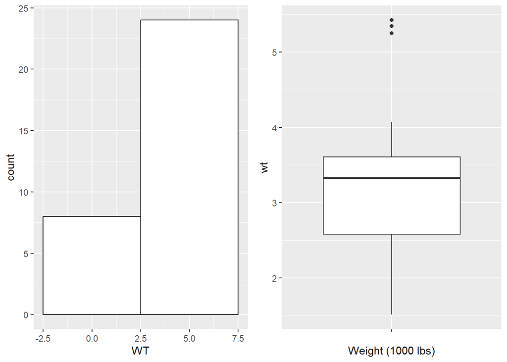

```r
box5<- ggplot(mtcars, aes(x="", y=wt))+
 geom_boxplot()+
 xlab("Weight (1000 lbs)")+
 ylab("wt")
hist5<-ggplot(mtcars, aes(x=wt))+
 geom_histogram(binwidth=5, fill="white", color="black")+
 xlab("WT")
grid.arrange(hist5, box5, ncol=2)
```

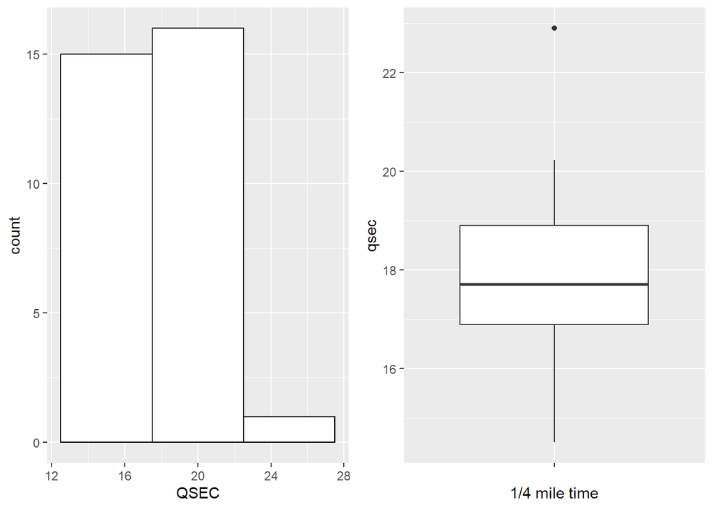

```r
box6<- ggplot(mtcars, aes(x="", y=qsec))+
 geom_boxplot()+
 xlab("1/4 mile time")+
 ylab("qsec")
hist6<-ggplot(mtcars, aes(x=qsec))+
 geom_histogram(binwidth=5, fill="white", color="black")+
 xlab("QSEC")
grid.arrange(hist6, box6, ncol=2)
```

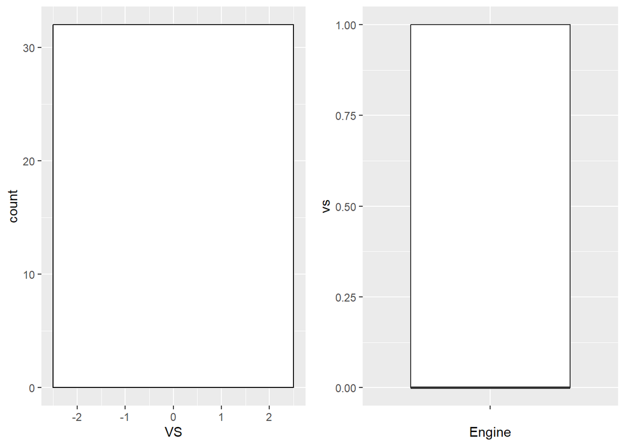

```r
box7<- ggplot(mtcars, aes(x="", y=vs))+
 geom_boxplot()+
 xlab("Engine")+
 ylab("vs")
hist7<-ggplot(mtcars, aes(x=vs))+
 geom_histogram(binwidth=5, fill="white", color="black")+
 xlab("VS")
grid.arrange(hist7, box7, ncol=2)
```

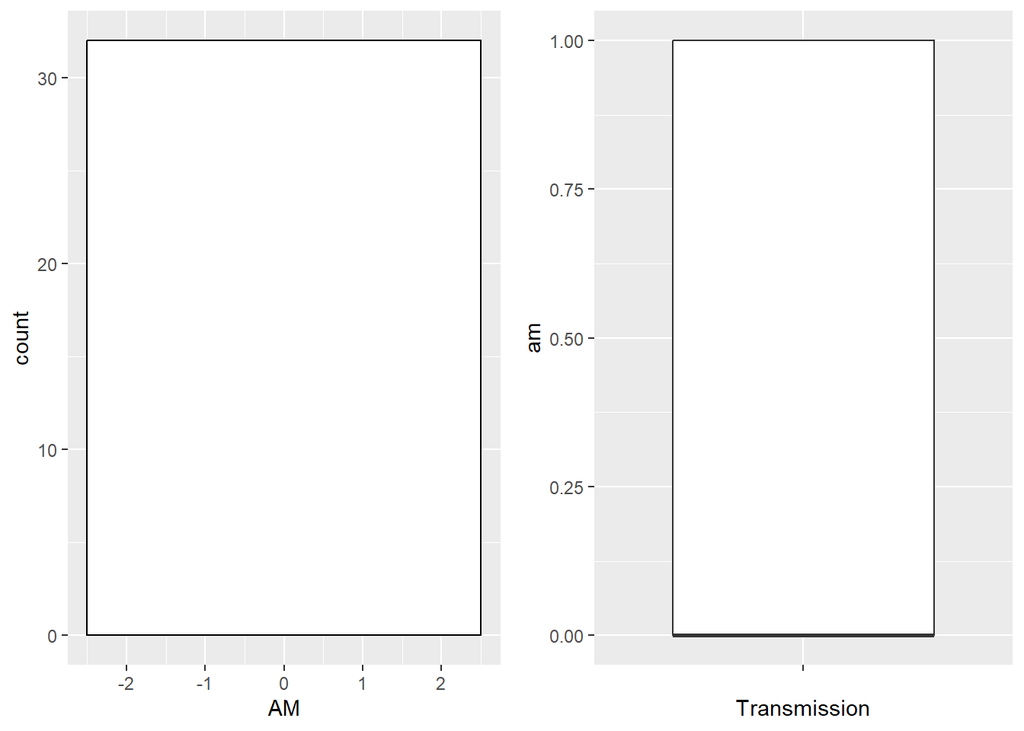

```r
box8<- ggplot(mtcars, aes(x="", y=am))+
 geom_boxplot()+
 xlab("Transmission")+
 ylab("am")
hist8<-ggplot(mtcars, aes(x=am))+
 geom_histogram(binwidth=5, fill="white", color="black")+
 xlab("AM")
grid.arrange(hist8, box8, ncol=2)
```

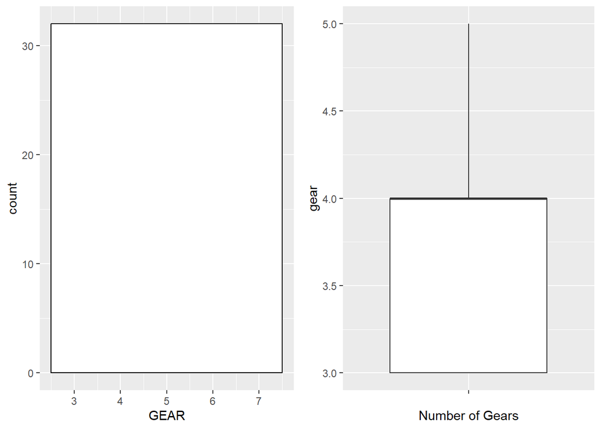

```r
box9<- ggplot(mtcars, aes(x="", y=gear))+
 geom_boxplot()+
 xlab("Number of Gears")+
 ylab("gear")
hist9<-ggplot(mtcars, aes(x=gear))+
 geom_histogram(binwidth=5, fill="white", color="black")+
 xlab("GEAR")
grid.arrange(hist9, box9, ncol=2)
```

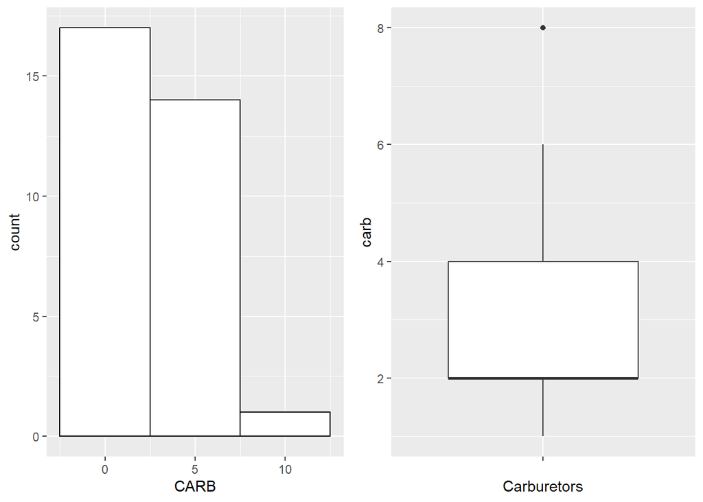

```r
box10<- ggplot(mtcars, aes(x="", y=carb))+
 geom_boxplot()+
 xlab("Carburetors")+
 ylab("carb")
hist10<-ggplot(mtcars, aes(x=carb))+
 geom_histogram(binwidth=5, fill="white", color="black")+
 xlab("CARB")
grid.arrange(hist10, box10, ncol=2)
```

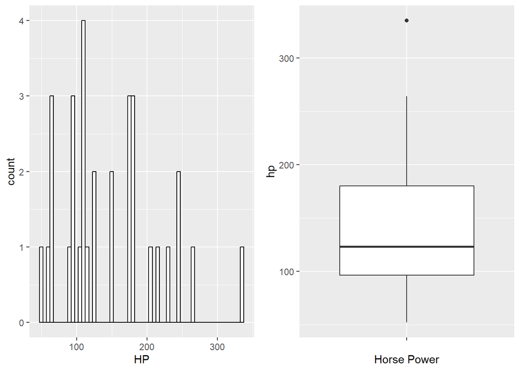

```r
box11<- ggplot(mtcars, aes(x="", y=hp))+
 geom_boxplot()+
 xlab("Horse Power")+
 ylab("hp")
hist11<-ggplot(mtcars, aes(x=hp))+
 geom_histogram(binwidth=5, fill="white", color="black")+
 xlab("HP")
grid.arrange(hist11, box11, ncol=2)
```

```r
summary(mtcars$disp) #we did this previously
```

```
##    Min. 1st Qu.  Median    Mean 3rd Qu.    Max.
##    71.1   120.8   196.3   230.7   326.0   472.0
```

# 4. What do you notice about the binwidth for some of the histograms? Do you need to change it for some of the variables?

# The binwidth is sometimes too big or too small for the plots

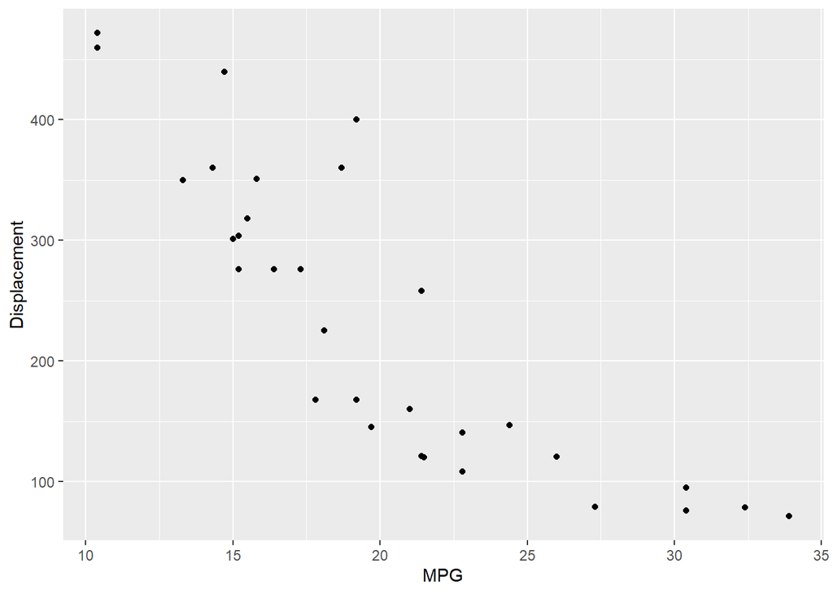

```r
library("ggplot2")
scat1<- ggplot(mtcars, aes(x=mpg, y=disp))+
 geom_point()+
 xlab("MPG")+
 ylab("Displacement")
scat1
```

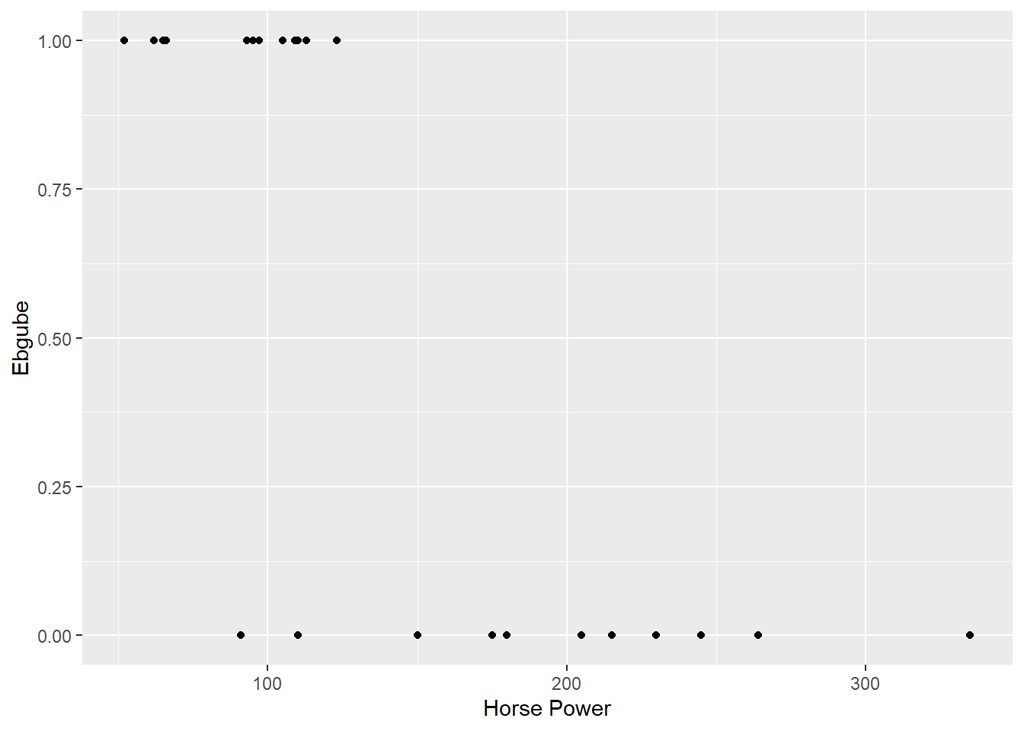

```r
scat2<- ggplot(mtcars, aes(x=hp, y=vs))+
 geom_point()+
 xlab("Horse Power")+
 ylab("Ebgube")
scat2
```

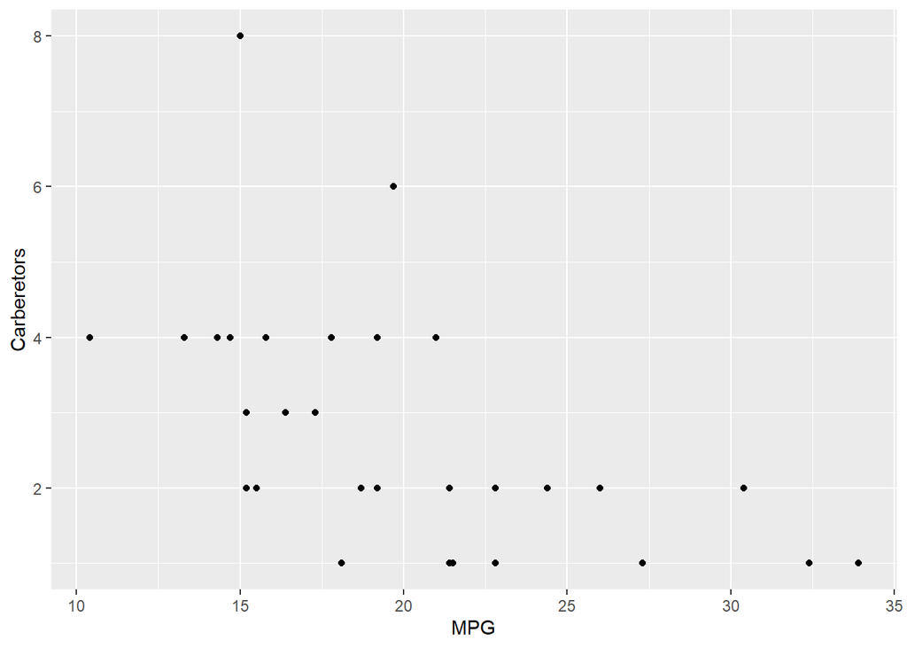

```r
scat3<- ggplot(mtcars, aes(x=mpg, y=carb))+
 geom_point()+
 xlab("MPG")+
 ylab("Carberetors")
scat3
```

# 5. We will often want to observe a relationship between two variables: scatterplots. The code below from the ggplot2 allows us to do create a scatterplot:

# What does the scatterplot suggest about the relationship between miles per gallon and displacement?

# the more displacecment the less miles per gallon

# 6. Create two more scatterplots from mtcars and comment on the relationships between the two variables that you have chosen to observe in each scatterplot. Remember to use the grid.arrange function to organise the plots.

# when engine is 1, less horsepower and vice versa

# more carberetors, less miles per gallon

```r
# These packages will need to be installed
#install.packages("httr")
#install.packages("jsonlite")
# Require (load) the packages
library(httr)
library(jsonlite)
```

```r
library(httr)
library(jsonlite)
# To obtain access, we need the API key
api_key <- "f0063370"
# Specify the title of which movie to search for (replace spaces with +)
movie <- "The+Banshees+of+Inisherin"
# Create a web path
path <- paste("http://www.omdbapi.com/?t=",movie,"&apikey=",api_key,sep="")
# Access HTTP data using GET command
call <- GET(url=path)
# To see if a HTTP request is successful, check the reply status code (successful code is 200)
status_code(call)
```

```
## [1] 401
```

```r
# To view the content of the call, the number of characters is truncated here for display only.
str(content(call), nchar.max=40) # remove ``nchar.max'' for all info
```

```
## List of 2
##  $ Response: chr "False"
##  $ Error   : chr "Invalid API key!"
```

```r
# Data are currently in JSON format, needs to be converted to text
text_call <- content(call,as="text",encoding="UTF-8")
df <- fromJSON(text_call,flatten=T)
head(df) # the first few items are shown for display only, run ``df'' for all info.
```

```
## $Response
## [1] "False"
##
## $Error
## [1] "Invalid API key!"
```

# I was unable to search up another movie because the API key was not being accepted even though I got my own one via email.